# SPS 506 · Class 7

## Research Design and Data Collection II

SPS 506 · Public Program Evaluation · October 15, 2026

Research Design and  
Data Collection II

How you ask decides what you hear: surveys, interviews, focus groups, stories

## Last week: three questions to answer before you design an evaluation

Class 6 review · OPE’s evaluation of how Idaho oversees children’s residential care

1**Is the program ready?**Evaluability assessment · Wholey, ch. 4. Ready when goals are agreed on, information needs are defined, the data exist, and someone will use the answer*Idaho: no definition of abuse in facilities, and no statewide count of restraints*

2**What do the records say?**Agency records · Hatry, ch. 13. Records go wrong six ways: missing, inaccurate, too aggregated, definitions, linking, confidentiality*Idaho: 51 of 59 abuse calls logged “no further action,” but staff said 44 got more*

3**What will you see when you go?**Fieldwork · Nightingale and Rossman, ch. 17. Whoever picks the visit and the interviewees shapes what you see*Idaho: inspections were announced, and the facility picked who was interviewed*

Last week: **check each source against the others**, including interviews. Tonight goes deeper on **how to ask people**: surveys, interviews, focus groups, and stories.

Class 6. OPE, *State Oversight of Children’s Residential Care* (2025), pp. 17, 32, 35–37, 50

## The Legislature asked OPE to evaluate Idaho’s largest online school

Idaho Home Learning Academy · back to our first night

**The school**

A public virtual charter school, authorized by the Oneida School District in Malad City.

It grew from 238 students in 2016–17 to about 7,600 K–12 students statewide in 2024–25, with $47.8 million in state funding.

Families get supplemental learning funds to buy their own curriculum. Parents act as “learning coaches,” and certified teachers are supposed to provide the instruction.

**The question**

In March 2025, the Legislature’s oversight committee asked its evaluation office, OPE, to evaluate IHLA. Legislators were worried about its fast growth, its state funding, and its students’ performance and accountability.

OPE set out to answer: Who does IHLA serve, and what is the student experience? How do its students perform? Do the learning funds go where state money is meant to go?

**OPE asked families:** Why did you choose IHLA? What do you and the teacher each do? How much do the learning funds matter? And families who had left: why did you go?

**OPE asked teachers:** Which of IHLA’s teacher duties describe your actual job? What do you think of state testing?

OPE, *Idaho Home Learning Academy* (2025), pp. 5, 11, 18, 28, 30, 35, 37, 91, 93–94. Surveys went to families in September 2025 and to teachers in October.

## OPE surveyed four IHLA groups in 2025, and they answered at very different rates

Idaho Home Learning Academy · OPE surveys, September–October 2025

If you wanted to know why families leave IHLA, whose answers would you need most?

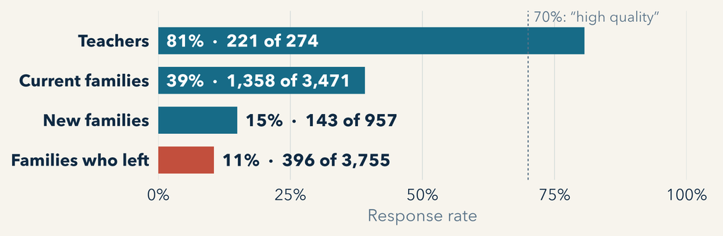

**Current:** enrolled in 2024–25 and still enrolled · **New:** first year was 2024–25 · **Left:** left IHLA before 2024–25

OPE, *Idaho Home Learning Academy* (2025), pp. 93–94; rates computed from OPE’s counts. 70% line: Newcomer and Triplett, ch. 14, p. 375

## Tonight: four ways to ask people, and what each one does best

**Survey****Counts across many people**Same questions, many people, numbers you can generalize · ch. 14

**Interview****Each person’s reasons, in their own words**One person at a time, follow each answer where it goes · ch. 19

**Focus group****The range of reactions in a group**A small group alike on one thing, talking to each other · ch. 20

**Story****One person’s experience, start to finish**Collected on purpose, with a method you can describe · ch. 21

Your **November 12 data collection plan** names a method for each question in your **October 29 design matrix**: records, observation, or one of these.

## Surveys

Part 1

Surveys

Newcomer and Triplett, “Using Surveys,” Handbook ch. 14

## A survey asks many people the same questions so the answers can be counted

Survey basics · Newcomer and Triplett, ch. 14

**What it is**

The same written questions for everyone in a group, or in a sample drawn from it.

Most questions come with set answer choices, so responses can be tallied.

**How it works**

Given by mail, web or email, phone, or in person.

You decide who to ask, how to reach them, what to ask, and how to test the questions before launch (Table 14.1).

**What you get**

Counts and percentages: how many, how much.

With a random sample, results generalize to the whole group within a margin of error. Surveys are weaker at explaining why.

**Example:** OPE’s IHLA surveys, one for current families, a shorter one for new families and families who had left, and one for teachers

Newcomer and Triplett, Handbook ch. 14: design matrix, Table 14.1, p. 346; modes, pp. 361, 367–369; random samples, p. 357. OPE, *Idaho Home Learning Academy* (2025), pp. 93–94

## A survey of a program’s clients misses the people it never served

The chapter’s example: a Legal Aid office wants to know how well it meets its community’s legal needs

Population**Everyone your question is about**

List you can reach**The people you have contact information for**Who isn’t on the list?

Sample**The people you pick to ask**Picked at random, or picked because they were easy?

Respondents**The people who answer**Are they different from the ones who didn’t?

Clients Legal Aid representedEasy: they’re in the agency’s records

Applicants Legal Aid turned downMissing from a client survey

Eligible people who never appliedMissing from a client survey

Newcomer and Triplett, Handbook ch. 14, Exhibit 14.1, pp. 348–350

## Quadrupling a random sample cuts the margin of error in half

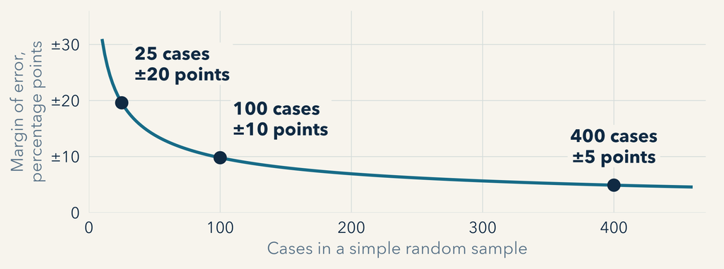

A random sample of a few hundred is usually enough. A **convenience sample** can’t be generalized at any size, because the people who chose to answer may differ from those who didn’t.

Newcomer and Triplett, ch. 14, p. 357 and Table 14.3, p. 358; Wholey, ch. 4, p. 105. Curve: 95% confidence, a proportion near 50%, 1.96 × √(0.25 ÷ n)

## Four common mistakes in survey questions, and how to fix them

A survey of community college students about career services

Mistake

Instead of

Ask

Two things

How satisfied were you with the résumé workshop and your career counselor?

Two questions: one about the workshop, one about the counselor

Leading

Don’t you agree that the résumé workshop was useful?

On a scale from 1 (not at all useful) to 7 (extremely useful), how useful was the résumé workshop?

Time frame

How often do you use career services?

In the past three months, how many times did you meet with a career counselor?

Unbalanced

Rate your counselor: Excellent · Very good · Good · Fair

1 (very poor) to 5 (very good), the same number of options on each side of the middle

Newcomer and Triplett, ch. 14, Box 14.6, p. 365 (13 common mistakes) and Box 14.4, p. 363. Career-services example from the Handbook instructor’s guide

## Follow-ups, prepaid incentives, and short questionnaires raise response rates

**Contact people more than once**“The most important factor.” The standard is two or three mailings, with reminders.

**Pay up front, in cash**For mail surveys, a small prepaid incentive works better than a promised one, and money beats gifts.

**Keep it short**Every extra question costs responses. A mail survey should fit on two to four pages.

Under 70%: check whether the people who didn’t answer are different. From 50 to 70%, weighting can help

70% and up: “high quality”

Newcomer and Triplett, ch. 14: contacts, p. 376; incentives, Box 14.3, p. 361; length, p. 362; thresholds, pp. 375, 379

## Interviews

Part 2

Interviews

Adams, “Conducting Semi-Structured Interviews,” Handbook ch. 19

## A semi-structured interview talks with one person at a time and follows up on each answer

Interview basics · Adams, ch. 19

**What it is**

A conversation with one person, built on a guide of core questions.

It mixes closed questions with open ones, then asks “why” or “how” to follow up.

**How it works**

About an hour at most.

Often a team of two, one asking and one taking notes. Recording is a judgment call.

Interviewees are drawn at random or by category, not picked by managers.

**What you get**

Each person’s reasons and experiences in their own words, plus counts from the closed questions.

Not statistical precision: for that, a survey of 600 beats 600 hour-long interviews.

**Example:** OPE’s IHLA study included more than 40 interviews with IHLA and district leaders, staff, parents, and state education offices

Adams, Handbook ch. 19: pp. 493, 495, 500–501, 504. OPE, *Idaho Home Learning Academy* (2025), p. 92

## Interview findings need a methods note: who was interviewed, how they were chosen, and what they were asked

Last week’s case · OPE’s children’s residential care evaluation

OPE: “We interviewed 66 individuals including department employees, legislators, community stakeholders, families …, and facility administrators.” What would you want to know before you trusted those 66?

**Who**How many from each group?

**Chosen how**A random draw? Nominated by the department?

**Asked what**The same core questions for everyone in a group?

**Recorded how**Audio, or notes? Quoted exactly?

**Promised what**Confidentiality? To staff talking about their own agency?

Adams: you draw the names and give them to the managers, “rather than letting the managers personally pick which staff members are heard.” Last week: at Licensing’s inspections, the facility administrator picked which children and staff were interviewed.

OPE, *State Oversight of Children’s Residential Care* (2025), p. 77. Adams, Handbook ch. 19, p. 495

## An interview guide starts easy and saves the hard questions for last

1**Warm-up**How long have you worked here?

2**Easy, relevant**What does your job involve day to day?

3**Good things first**What works well in the program?

4**Improvements**What areas need improvement? Not “What’s bad?”

5**Sensitive**Near the end, after rapport. Repeat the promise of confidentiality

6**Demographics**Last, only what you need, in broad ranges

7**Close forward**An easy question about the future

Build rapportHard questionsWrap up

Try the guide on a few people first, and **revise it after the first interview**. If one person raises something serious, add it for everyone after.

Adams, ch. 19, pp. 496–499

## Ask a closed question, then “Why is that?” to get both a count and the reasons

Closed“Was the new intake process a major improvement, a minor improvement, or not an improvement?”

Then why“Why is that?” · “Can you give me an example?” · “Anything else?”

ReportTen of the twelve board members called it a major improvement. Here’s why, in their words …

If people might give the “right” answer, lower the stakes first: **“Some people tell us …. How do you see it?”**

Adams, ch. 19, pp. 497, 502–504

## Focus groups

Part 3

Focus groups

Krueger and Casey, “Focus Group Interviewing,” Handbook ch. 20

## A focus group is a moderated discussion among a small group of similar people

Focus group basics · Krueger and Casey, ch. 20

**What it is**

A planned discussion, led by a moderator through a set sequence of questions.

The goal is insight into how people see the topic, not agreement.

**How it works**

5 to 8 people for sensitive topics, up to 12 for everyday ones, alike on something related to the topic.

About 10 to 14 open-ended questions over two hours. Three or four groups of each type.

**What you get**

The range of views, the words people use, and how they react to each other’s ideas.

Not statistics: there are too few people to project to a population.

**Example (next slide):** participants in a smoking-cessation program, in focus groups a year after it ended

Krueger and Casey, Handbook ch. 20: definition, p. 506; size and makeup, pp. 510–511; number of groups, p. 511; limits, p. 513; questions, p. 516

## Focus groups show the range of reactions people have to a program

Participants in a smoking-cessation program liked it. In focus groups a year later, they brought up the phone surveys used to evaluate it without being asked, and said the surveys were tedious, confusing, and not worth taking seriously.

Use it to

- Learn what a community needs, in its own terms
- Get reactions to a plan, a form, or a message before you spend money
- Test a survey or a form before it goes out
- Explain a number: why ratings dropped after the system grew

Don’t use it

- To produce statistics (too few people to project to a population)
- To reach consensus or teach a skill
- If speaking up could hurt someone, since you can’t promise the others will keep quiet
- On a polarized topic, with people on both sides in one room

Krueger and Casey, Handbook ch. 20: smoking study, pp. 507–508; uses, p. 513; limits, pp. 513–514

## Stories

Part 4

Stories

Krueger, “Using Stories in Evaluation,” Handbook ch. 21

## An evaluation story is one person’s experience, collected on purpose

Story basics · Krueger, ch. 21

**What it is**

A short account of one person’s experience with a program.

You gather it with a method you can describe, which is what separates it from an anecdote you happened to hear.

**How it works**

Choose a topic and whose stories you need. Ask “Tell me about…” instead of asking for a “story.”

Record it, check it with the teller, and agree on how it can be used.

**What you get**

How and why something changed for one person, in a form people remember.

Stories can illustrate or explain survey results, show patterns across many tellers, or document success.

**Example:** at the VA, one father’s story about his son with PTSD led to a national directive

Krueger, Handbook ch. 21: definition, p. 537; uses, Table 21.1, pp. 539–543; VA example, pp. 542–543; steps, pp. 546–552; “tell me about,” p. 555

## A useful evaluation story follows one person through what they faced, what they did, and what happened

Staff in a hospital patient-safety evaluation kept saying management sent mixed signals. Then one told a hang-gliding story: the first flier off the mountain is the “wind dummy,” and everyone watches. “If that person crashes and burns, then the rest of us change our behavior accordingly.” Krueger, ch. 21, Box 21.2, p. 538

**A person**A participant or a staff member at the center of the story

**An obstacle**A problem, a goal, a dilemma

**A struggle**What they did, and how it felt

**A resolution**What happened, and the point

Krueger, Handbook ch. 21: story elements, p. 553

## A story counts as evidence only when you say how you got it and how typical it is

1**Planned**A topic and a method chosen in advance

2**Sourced**Whose story it is, even if not named

3**Verified**Read back to the teller: “Is this your story?”

4**Documented**How it was gathered and handled

5**Placed**Typical, unusual, or one of a kind?

**Level 1**Story and source

**Level 2**Story, no source

**Level 3**The general idea only

**Level 4**Don’t report it

Krueger, ch. 21: evidence, p. 538; confidentiality levels, pp. 549–550; representativeness, pp. 550–551

## Group activity: one question, four ways to ask

In groups · 12 minutes · one method per group: survey, interviews, focus groups, or stories

1The question: why do families leave IHLA? You’re designing a follow-up study. Every group answers the same question, each with its own method.

2Who would you ask, and how would you reach them? Families who left have moved on. Where would you find them, and who would you still miss?

3Write two or three questions you’d ask Survey group: check yours against tonight’s four mistakes (two things, leading, time frame, unbalanced)

4What kind of answer would you get? Report out in one minute: your best question, and what your method can’t tell you

## The Silver Affair

Case discussion · led by your classmates

The Silver Affair

A state lands bureau, a timber contract, and an analyst who wouldn’t let it go

## Before we leave

**October 22**

Outcome and impact evaluation: Handbook ch. 6 and 7, and skim GAO-10-30. Case: Women as Leaders

**October 29**

Design matrix due, by class time. Bring a printed copy. Case: Team Read (B)

**November 12**

Data collection plan due. Use tonight’s activity steps for each question in your plan

Whose voice is your evaluation most likely to miss, and how would you reach them?